# practice

### 8.7.3 色を増やす

```r
# デフォルトではPairedは12色のみ
many_col <- brewer.pal(12, "Paired")
many_col
```

```
##  [1] "#A6CEE3" "#1F78B4" "#B2DF8A" "#33A02C" "#FB9A99" "#E31A1C" "#FDBF6F"
##  [8] "#FF7F00" "#CAB2D6" "#6A3D9A" "#FFFF99" "#B15928"
```

```r
# 20色まで増やす
many_col <- colorRampPalette(many_col)(20)
many_col
```

```
##  [1] "#A6CEE3" "#579CC7" "#3688AD" "#8BC395" "#89CB6C" "#40A635" "#919D5F"
##  [8] "#F99392" "#EB494A" "#E83C2D" "#F79C5D" "#FDA746" "#FE8205" "#E39970"
## [15] "#BFA5CF" "#8861AC" "#917099" "#E7E099" "#DEB969" "#B15928"
```

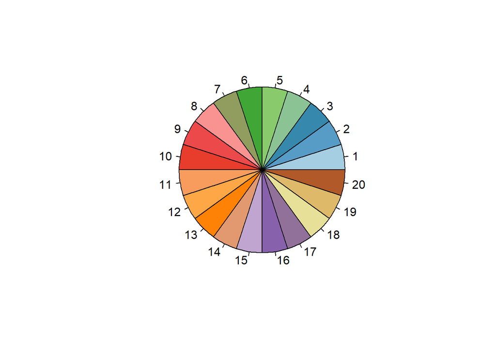

```r
pie(rep(1, length(many_col)), col = many_col, main = "")
```

### 8.7.4 デフォルトでたくさんあるpalsパッケージ

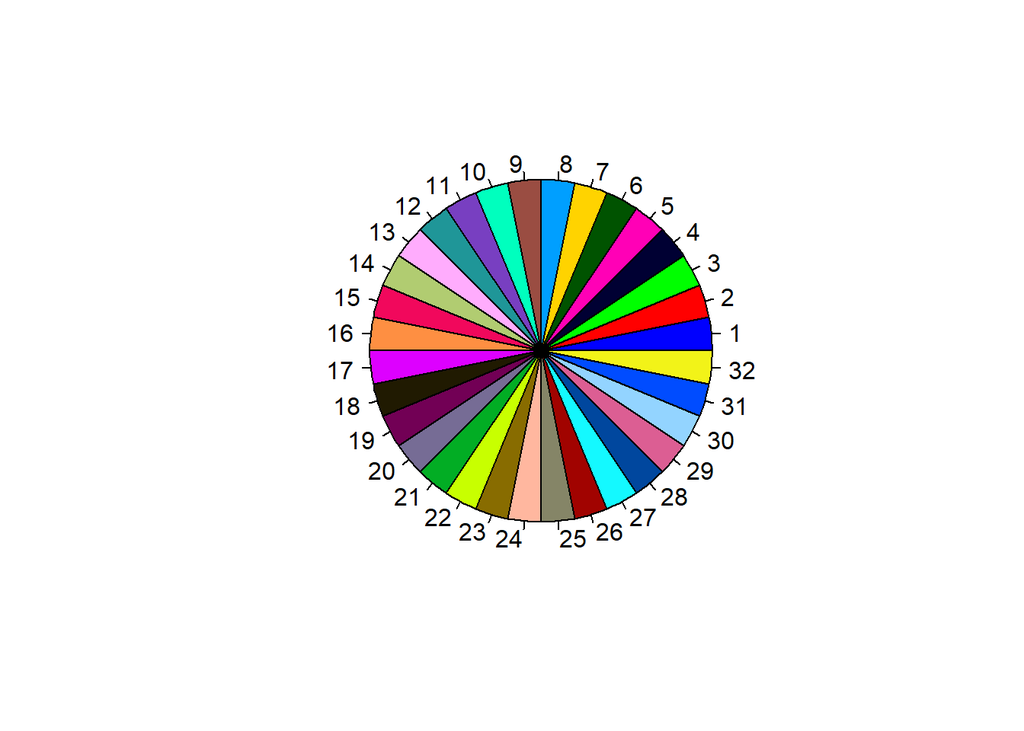

```r
library(pals)
many_col <- colorRampPalette(glasbey())(32)
pie(rep(1, length(many_col)), col = many_col, main = "")
```

## 8.8 ワッフルチャート

```r
# waffleパッケージをここだけで一時的に読んでいるためwaffle::としている


bfi |>
  tabyl(gender)
```

```
##  gender    n   percent
##       1  919 0.3282143
##       2 1881 0.6717857
```

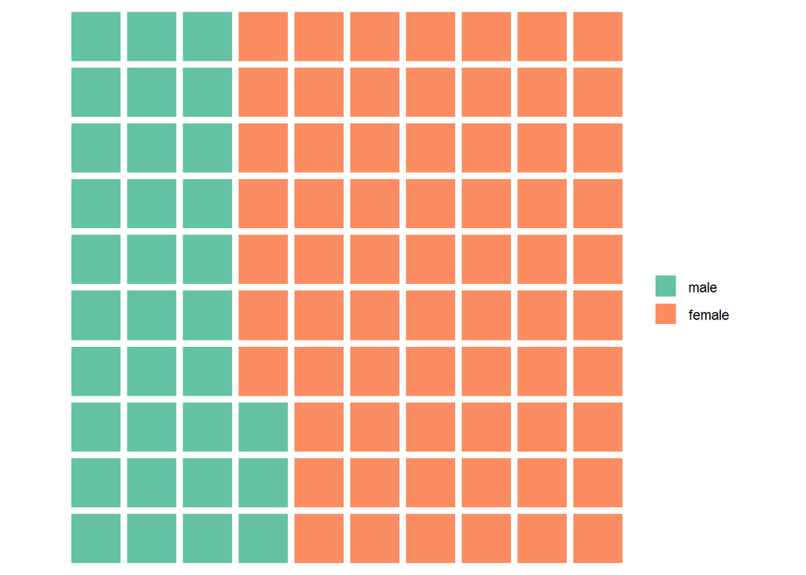

```r
parts <- c(male = 33, female = 67)
waffle::waffle(parts)
```

## 8.9 （動かないので修正中,現在CRANになし）人型グラフ

- 割合を人型の図の数で示す

## 8.10 設問ごとの可視化

- `likert()`はdata.frame形式
  - https://stackoverflow.com/questions/46646308/problems-with-r-likert-package
- 解説 + http://rstudio-pubs-static.s3.amazonaws.com/167534_c1fd7466282942599764b5ab1329d7e9.html

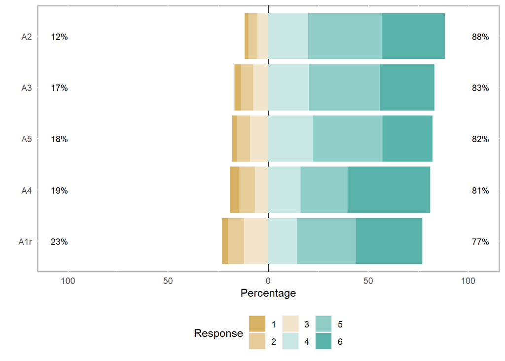

```r
library(likert)

bfi_lik <-
bfi_a |>
  select(A1r, A2:A5) |>
  mutate(across(everything(), factor)) |>
  as.data.frame() |> # data.frame形式
  likert()

plot(bfi_lik)
```

### 8.10.1 中心位置を変更

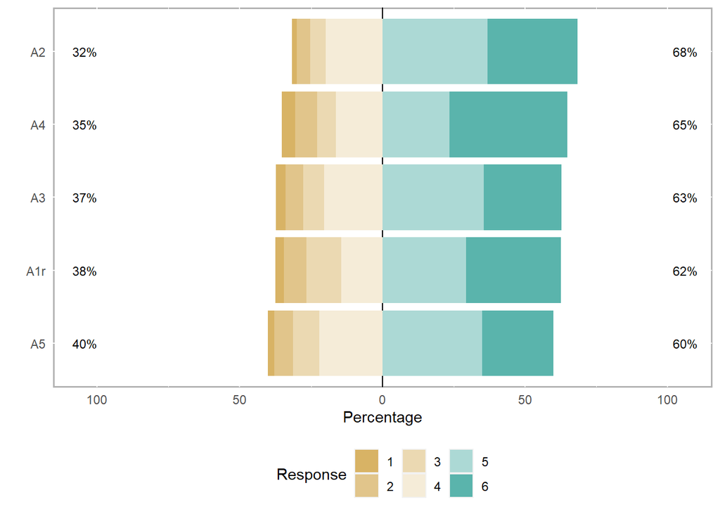

```r
plot(bfi_lik, center = 4.5)
```

### 8.10.2 ヒートマップ

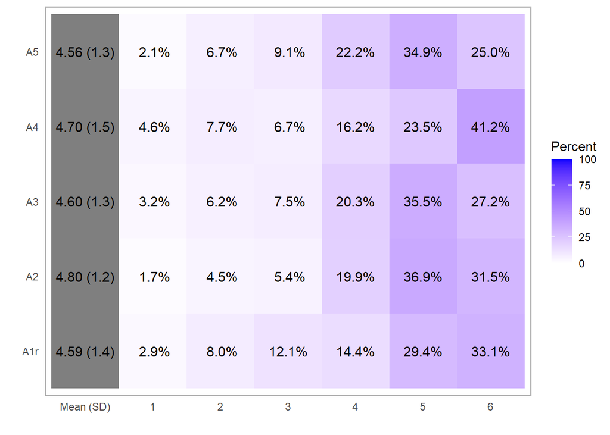

```r
plot(bfi_lik, type = "heat")
```

### 8.10.3 層別

[figure not shown]

```r
bfi_a <-
  bfi_a |>
 mutate(gender = factor(gender),
   gender = fct_recode(gender,
                            males = "1", females = "2"))  #Males = 1, Females =2

bfi_lik_gen <-
bfi_a |>
  select(A1r, A2:A5) |>
  mutate(across(everything(), factor)) |>
  as.data.frame() |> # data.frame形式
  likert(grouping = bfi_a$gender)


plot(bfi_lik_gen)
```

# 9 相関

## 9.1 ピアソンの積率相関

```r
cor(bfi$A2, bfi$A3, use = "complete.obs")
```

```
## [1] 0.485098
```

## 9.2 相関行列

```r
bfi |>
select(A1:A5) |>
cor(use = "complete.obs")
```

```
##            A1         A2         A3         A4         A5
## A1  1.0000000 -0.3416242 -0.2682817 -0.1483927 -0.1826790
## A2 -0.3416242  1.0000000  0.4867503  0.3352432  0.3877875
## A3 -0.2682817  0.4867503  1.0000000  0.3621720  0.5051762
## A4 -0.1483927  0.3352432  0.3621720  1.0000000  0.3067003
## A5 -0.1826790  0.3877875  0.5051762  0.3067003  1.0000000
```

## 9.4 ポリコリック相関

- Polychoric correlation
- 順序尺度と順序尺度の相関

```r
res <-
bfi |>
  select(A2, A3) |>
  polychoric( na.rm = TRUE)

res
```

```
## Call: polychoric(x = select(bfi, A2, A3), na.rm = TRUE)
## Polychoric correlations
##    A2   A3
## A2 1.00
## A3 0.56 1.00
##
##  with tau of
##       1    2     3     4    5
## A2 -2.1 -1.5 -1.19 -0.48 0.48
## A3 -1.8 -1.3 -0.96 -0.33 0.61
```

```r
res$rho
```

```
##          A2       A3
## A2 1.000000 0.555451
## A3 0.555451 1.000000
```

```r
# 相関係数だけを取り出す
res$rho[1,2]
```

```
## [1] 0.555451
```

```r
# 因子型にした場合（結果は同じ）
# bfi |>
#   select(A2, A3) |>
#   mutate_all(factor) |>
#   polychoric( na.rm = TRUE)
```

## 9.5 点双列相関

- point-biserial correlation
- 連続量と2値の相関

```r
# ltmパッケージをここだけで一時的に読んでいるためltm::としている
ltm::biserial.cor(bfi_a$total_a, bfi_a$gender, use = "complete.obs")
```

```
## [1] -0.2075376
```

```r
# ピアソンの積率相関で出した場合
bfi_a <-
  bfi_a |>
  mutate(gender_n = as.numeric(gender))

cor(bfi_a$total_a, bfi_a$gender_n, use = "complete.obs")
```

```
## [1] 0.2075376
```

# 10 層別回帰

## 10.1 層別に重回帰

### 10.1.1 データフレームをネストする

```r
library(broom)


bfi_n <-
bfi |>
  as_tibble() |>
  nest(!c(gender))

bfi_n
```

```
## # A tibble: 2 × 2
##   gender data
##    <int> <list>
## 1      1 <tibble [919 × 27]>
## 2      2 <tibble [1,881 × 27]>
```

### 10.1.2 回帰モデルをネストする

- 上から読んでいったら，`Error: Corrupt x: no names`が出たので，`map()`とぶつかりそうなパッケージをここで外す

```r
bfi_n <-
bfi_n |>
  mutate(
    fit = map(data, \(x) lm(A5 ~ A1 + A4, data = x))
              )

# purrr 1.0.0より前
# bfi_n <-
# bfi_n  %>%
#   mutate(
#     fit = map(data, ~ lm(A5 ~ A1 + A4, data = .)))

bfi_n
```

```
## # A tibble: 2 × 3
##   gender data                  fit
##    <int> <list>                <list>
## 1      1 <tibble [919 × 27]>   <lm>
## 2      2 <tibble [1,881 × 27]> <lm>
```

```r
## 古いやり方
# fit <-
#   bfi |>
#   group_by(gender) |>
#   do(data = lm(A5 ~ A1 + A4 ,
#                data = .) |>
#        tidy()
#   )
# res_fit <-
#   bfi_n |>
#   unnest()
```

### 10.1.3 ネストを解除して回帰係数を出力

```r
res_fit <-
bfi_n |>
  mutate(fit = map(fit, tidy)) |>
  unnest(fit) |>
  select(!data)


# tidyr 0.8.3までのやり方
# res_fit <-
# bfi_n |>
#   unnest(fit |> map(tidy))

res_fit
```

```
## # A tibble: 6 × 6
##   gender term        estimate std.error statistic   p.value
##    <int> <chr>          <dbl>     <dbl>     <dbl>     <dbl>
## 1      1 (Intercept)    3.53     0.160      22.0  3.09e- 86
## 2      1 A1            -0.132    0.0290     -4.54 6.24e-  6
## 3      1 A4             0.274    0.0279      9.81 1.14e- 21
## 4      2 (Intercept)    3.83     0.109      35.2  4.48e-208
## 5      2 A1            -0.113    0.0199     -5.71 1.34e-  8
## 6      2 A4             0.222    0.0186     11.9  1.01e- 31
```

### 10.1.4 ネストを解除してR二乗を出力

```r
bfi_n |>
  mutate(fit = map(fit, glance)) |>
  unnest(fit) |>
  select(!data)
```

```
## # A tibble: 2 × 13
##   gender r.squared adj.r.squared sigma statistic  p.value    df logLik   AIC
##    <int>     <dbl>         <dbl> <dbl>     <dbl>    <dbl> <dbl>  <dbl> <dbl>
## 1      1    0.125         0.123   1.24      65.1 3.79e-27     2 -1485. 2979.
## 2      2    0.0968        0.0959  1.16      98.5 2.21e-41     2 -2881. 5769.
## # ℹ 4 more variables: BIC <dbl>, deviance <dbl>, df.residual <int>, nobs <int>
```

```r
# bfi_n |>
#   unnest(fit |> map(glance))
```

## 10.3 回帰係数を棒グラフで表示

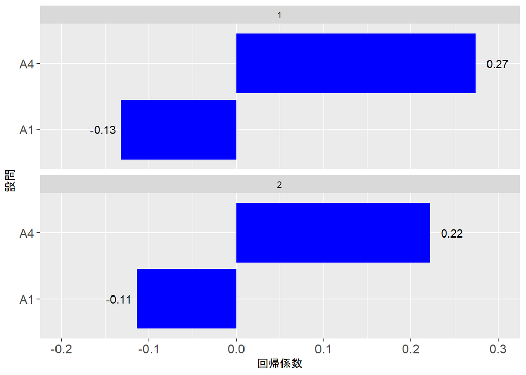

```r
res_fit |>
  filter(term != "(Intercept)") |>
  ggplot(aes(x = term, y = estimate)) +
  geom_col(fill = "blue") +
  geom_text(aes(label = round(estimate,2),
                hjust = if_else(estimate > 0, -0.5, 1.2) # 係数の値がマイナスだったら逆方向の位置に
                )
            ) +
    scale_y_continuous(limits = c(-0.2, 0.3)) +          # 軸の表示範囲を指定
  theme(
    axis.text.x = element_text(size = 12),               # x軸の文字の大きさ
    axis.text.y = element_text(size = 12)) +             # y軸の文字の大きさ
  labs(x = "設問", y = "回帰係数") +
   coord_flip() +                                        # グラフを横向きに（x軸とy軸が入れ替わる）
  facet_wrap(~ gender, ncol = 1)
```

## 10.4 回帰係数と信頼区間を表示

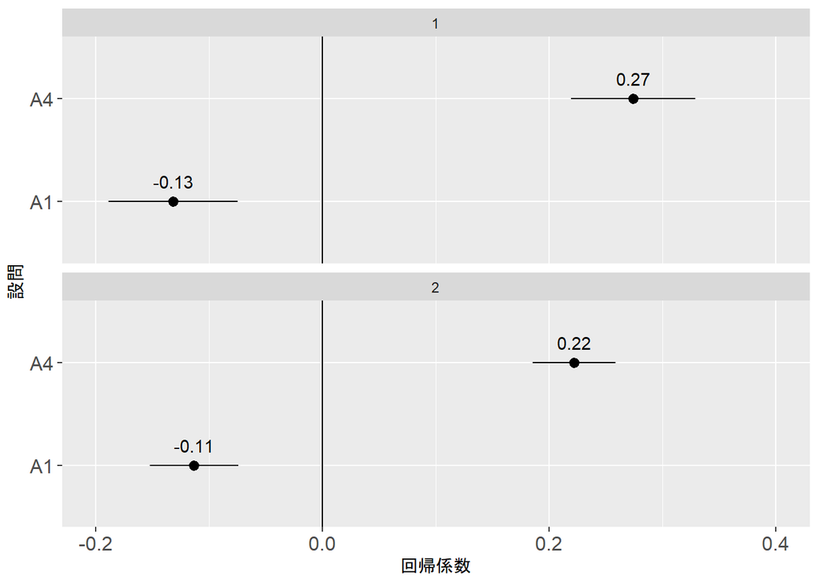

```r
res_fit <-
bfi_n |>
  mutate(fit = map(fit, tidy, conf.int = TRUE)) |>
  unnest(fit) |>
  select(!data)


# res_fit <-
# bfi_n |>
#   unnest(fit |> map(tidy, conf.int = TRUE))


res_fit |>
  filter(term != "(Intercept)") |>
  ggplot(aes(x = term, y = estimate)) +
  geom_pointrange(aes(ymin = conf.low, ymax = conf.high)) +
  geom_text(aes(label = round(estimate,2),
                vjust = -1                        # 係数の値がマイナスだったら逆方向の位置に
                )
            ) +
  geom_hline(yintercept = 0) +                    # 係数が0の位置に線を表示
  scale_y_continuous(limits = c(-0.2, 0.4)) +     # 軸の表示範囲を指定
  theme(
    axis.text.x = element_text(size = 12),        # x軸の文字の大きさ
    axis.text.y = element_text(size = 12)) +      # y軸の文字の大きさ
  labs(x = "設問", y = "回帰係数") +
  coord_flip() +                                  # グラフを横向きに
  facet_wrap(~ gender, ncol = 1)
```

# 11 回帰：アウトカムが複数の場合

## 11.1 それぞれの回帰を実行し結果をリストに格納

```r
# 対象となるアウトカムをオブジェクトに
outcomes <-
  bfi |>
  select(A3:A5) |>
  names()

# それぞれの回帰を実行しリストに格納
res_l <-
outcomes %>% # native pipeが使えないので
  str_c(., "~ A1 + A2") %>%
  map(\(x) lm(as.formula(x), data = bfi)) |>
  set_names(outcomes)
```

## 11.2 結果を1つのデータフレームにまとめる

```r
res_l %>%
  map(\(x) tidy(x, conf.int = TRUE)) |>
  bind_rows(.id = "outcome")
```

```
## # A tibble: 9 × 8
##   outcome term        estimate std.error statistic   p.value conf.low conf.high
##   <chr>   <chr>          <dbl>     <dbl>     <dbl>     <dbl>    <dbl>     <dbl>
## 1 A3      (Intercept)   2.48      0.116      21.4  4.73e- 94   2.25    2.71
## 2 A3      A1           -0.106     0.0164     -6.45 1.31e- 10  -0.138  -0.0736
## 3 A3      A2            0.495     0.0196     25.2  1.76e-126   0.457   0.533
## 4 A4      (Intercept)   2.83      0.143      19.8  1.00e- 81   2.55    3.11
## 5 A4      A1           -0.0387    0.0202     -1.92 5.49e-  2  -0.0783  0.000817
## 6 A4      A2            0.408     0.0242     16.9  9.48e- 61   0.360   0.455
## 7 A5      (Intercept)   2.79      0.118      23.5  1.36e-111   2.55    3.02
## 8 A5      A1           -0.0517    0.0167     -3.09 2.02e-  3  -0.0846 -0.0189
## 9 A5      A2            0.395     0.0200     19.7  6.41e- 81   0.356   0.434
```

# 12 回答のパターンチェック

## 12.1 全て同じ人を特定

- https://stackoverflow.com/questions/37980536/how-can-i-write-an-r-script-to-check-for-straight-lining-i-e-whether-for-any

```r
bfi_only <-
  bfi |>
  select(A1:O5)


bfi_only$all_same <-
  apply(bfi_only, 1, function(row) all(row == row[1]))


bfi_only |>
  count(all_same)
```

```
##   all_same    n
## 1    FALSE 2779
## 2     TRUE    4
## 3       NA   17
```

```r
# 次のパッケージで検討のため削除
bfi_only <-
  bfi_only |>
  select(!all_same)
```

## 12.2 carelessパッケージ

- https://github.com/ryentes/careless
- 個人ごとに回答のSDを算出

```r
bfi_only |>
careless::irv() |>
  enframe(name = "id", value = "sd")
```

```
## # A tibble: 2,800 × 2
##    id       sd
##    <chr> <dbl>
##  1 61617  0.9
##  2 61618  1.29
##  3 61620  1.09
##  4 61621  1.17
##  5 61622  1
##  6 61623  1.86
##  7 61624  1.61
##  8 61629  1.52
##  9 61630  1.50
## 10 61633  1.70
## # ℹ 2,790 more rows
```

```r
# 全体 + 分割して算出（回答の前半と後半で比べるとか）
bfi_only |>
careless::irv(split = TRUE, num.split = 4) |>
  head()
```

```
##       irvTotal      irv1      irv2      irv3      irv4
## 61617 0.900000 0.8997354 0.5163978 0.9831921 1.2110601
## 61618 1.294862 1.3451854 1.9407902 0.8366600 1.0488088
## 61620 1.092398 0.5345225 1.2247449 1.0954451 1.3784049
## 61621 1.166190 0.7867958 0.9831921 1.2247449 1.3291601
## 61622 1.000000 0.9759001 1.4719601 1.0327956 0.4082483
## 61623 1.863688 0.4879500 2.3166067 1.7224014 1.7511901
```

# 13 クロンバックのアルファ

- 因子ごとのdfに分割して，必要な情報を抽出して統合したdf作成
- ※要確認
  - factor_meanとfactor_sdが，listwiseの値と違う？→算出プロセスが分からないので不使用

```r
# それぞれの因子の構成設問群をリストに（反転済み変数名）
factor_items <-
  list(agree = c("A1_r","A2","A3","A4","A5"),
       conscientious = c("C1","C2","C3","C4_r","C5_r"),
       extraversion = c("E1_r","E2_r","E3","E4","E5"),
       neuroticism = c("N1","N2","N3","N4","N5"),
       openness = c("O1","O2_r","O3","O4","O5_r"))

# 各因子に対応する項目のみのdfのリスト作成
bfi_by_factor <-
    map(factor_items, \(x) select(bfi_added, all_of(x)))

# 各dfでalpha()実行
res <-
  map(bfi_by_factor, alpha)


# 各結果からtotal要素を抜き出す
res_alpha <-
  map_df(res, "total", .id = "factor") |>  # 必要なのはraw_alpha
  select(factor, alpha = raw_alpha, factor_mean = mean, factor_sd = sd)


# 各結果からalpha.drop要素を抜き出す
alpha_item_del <-
  map_df(res, "alpha.drop", .id = "factor") |>
  select(factor, alpha_if_del = raw_alpha) |>
  rownames_to_column(var = "item")

# 各結果からitem.stats要素を抜き出す
ir <-
  map_df(res, "item.stats", .id = "factor") |>
  select(factor, r.drop, mean, sd) |>
  rownames_to_column(var = "item")

# 各結果からresponse.freq要素を抜き出す（数値の列名がうまく読み込めないので一度mapで処理）
freq <-
  map(res, "response.freq") |>
  map(\(x) as_tibble(x, rownames = "item")) |>
  map(\(x) select(x, item,
               answer_1 = "1",
               answer_2 = "2",
               answer_3 = "3",
               answer_4 = "4")) |>
  bind_rows()



# 連結
res_alpha_df <-
alpha_item_del |>
  left_join(ir) |>
  left_join(freq) |>
  left_join(res_alpha)



# 変数並び変え
res_alpha_df <-
  res_alpha_df |>
  relocate(factor, item, factor_mean, factor_sd, alpha, alpha_if_del, r.drop, mean, sd, answer_1:answer_4)

res_alpha_df |>
  head()
```

```
##          factor item factor_mean factor_sd     alpha alpha_if_del    r.drop
## 1         agree A1_r    4.652095 0.8984019 0.7030184    0.7185174 0.3084177
## 2         agree   A2    4.652095 0.8984019 0.7030184    0.6171800 0.5636152
## 3         agree   A3    4.652095 0.8984019 0.7030184    0.6002596 0.5870046
## 4         agree   A4    4.652095 0.8984019 0.7030184    0.6858057 0.3944441
## 5         agree   A5    4.652095 0.8984019 0.7030184    0.6429530 0.4885651
## 6 conscientious   C1    4.265732 0.9513469 0.7267350    0.6940004 0.4502417
##       mean       sd   answer_1   answer_2   answer_3  answer_4
## 1 4.586566 1.407737 0.02945402 0.08010057 0.12104885 0.1443966
## 2 4.802380 1.172020 0.01694915 0.04543815 0.05445366 0.1994230
## 3 4.603821 1.301834 0.03244412 0.06200433 0.07462149 0.2033165
## 4 4.699748 1.479633 0.04638619 0.07731032 0.06652283 0.1621719
## 5 4.560345 1.258512 0.02119253 0.06681034 0.09123563 0.2216236
## 6 4.502339 1.241347 0.02626844 0.05793451 0.09895646 0.2356963
```

```r
# 不要オブジェクト削除
rm(factor_items,alpha_item_del, ir, freq, res_alpha, res_alpha_df)
```

## 13.1 確認

# 14 共分散構造分析

- https://lavaan.ugent.be/tutorial/index.html
- https://stats.idre.ucla.edu/r/seminars/rcfa/

## 14.1 CFA

agree = A1_r + A2 + A3 + A4 + A5  
conscientious = C1 + C2 + C3 + C4_r + C5_r  
extraversion = E1_r + E2_r + E3 + E4 + E5  
neuroticism = N1 + N2 + N3 + N4 + N5  
openness = O1 + O2_r + O3 + O4 + O5_r

```r
library(lavaan)

model1 <-  'A  =~ A1 + A2 + A3 + A4 + A5
            C  =~ C1 + C2 + C3 + C4 + C5'

fit <- cfa(model1, data = bfi_added)
summary(fit, fit.measures = TRUE, standardized = TRUE)
```

```
## lavaan 0.6.15 ended normally after 40 iterations
##
##   Estimator                                         ML
##   Optimization method                           NLMINB
##   Number of model parameters                        21
##
##                                                   Used       Total
##   Number of observations                          2632        2800
##
## Model Test User Model:
##
##   Test statistic                               503.340
##   Degrees of freedom                                34
##   P-value (Chi-square)                           0.000
##
## Model Test Baseline Model:
##
##   Test statistic                              5469.721
##   Degrees of freedom                                45
##   P-value                                        0.000
##
## User Model versus Baseline Model:
##
##   Comparative Fit Index (CFI)                    0.913
##   Tucker-Lewis Index (TLI)                       0.885
##
## Loglikelihood and Information Criteria:
##
##   Loglikelihood user model (H0)             -42637.052
##   Loglikelihood unrestricted model (H1)     -42385.382
##
##   Akaike (AIC)                               85316.104
##   Bayesian (BIC)                             85439.489
##   Sample-size adjusted Bayesian (SABIC)      85372.766
##
## Root Mean Square Error of Approximation:
##
##   RMSEA                                          0.072
##   90 Percent confidence interval - lower         0.067
##   90 Percent confidence interval - upper         0.078
```

[output cut: 32 more lines]

```
##
## Variances:
##                    Estimate  Std.Err  z-value  P(>|z|)   Std.lv  Std.all
##    .A1                1.712    0.050   34.527    0.000    1.712    0.863
##    .A2                0.776    0.029   27.044    0.000    0.776    0.558
##    .A3                0.746    0.035   21.514    0.000    0.746    0.437
##    .A4                1.656    0.051   32.497    0.000    1.656    0.748
##    .A5                0.963    0.034   28.708    0.000    0.963    0.603
##    .C1                1.065    0.034   30.911    0.000    1.065    0.697
##    .C2                1.078    0.038   28.597    0.000    1.078    0.618
##    .C3                1.131    0.037   30.481    0.000    1.131    0.681
##    .C4                1.027    0.040   25.825    0.000    1.027    0.544
##    .C5                1.707    0.058   29.465    0.000    1.707    0.646
##     A                 0.271    0.032    8.611    0.000    1.000    1.000
##     C                 0.463    0.035   13.160    0.000    1.000    1.000
```

### 14.1.1 パス図1

- https://cran.r-project.org/web/packages/tidySEM/vignettes/Plotting_graphs.html

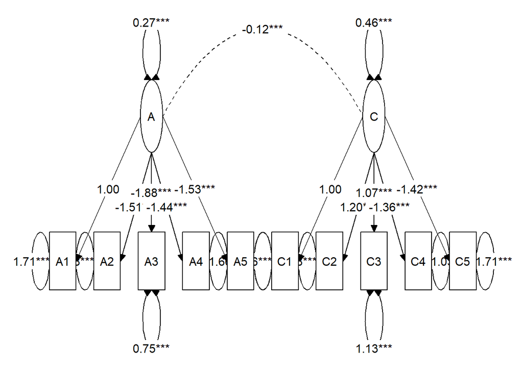

```r
library(tidySEM)

lay <- get_layout("", "", "A","","", "", "","C","", "",
                  "A1", "A2", "A3", "A4", "A5", "C1", "C2", "C3", "C4","C5", rows = 2)

graph_sem(fit, layout = lay)
```

### 14.1.2 パス図2

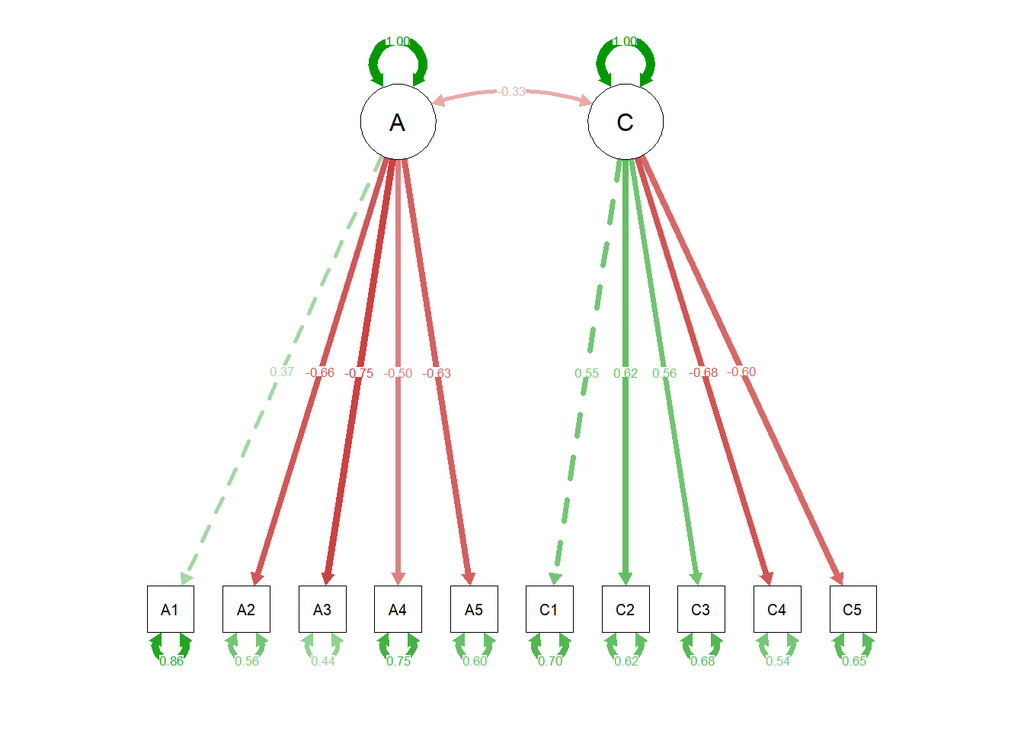

```r
semPlot::semPaths(fit, "std")
```

### 14.1.3 適合度指標のみ

```r
res_fit <-
fitMeasures(fit,c("cfi","tli",
                "rmsea","rmsea.ci.lower","rmsea.ci.upper",
                "srmr"))
# 整形
res_fit <-
res_fit |>
  enframe() |>
  mutate(value = as.numeric(value))
# |>
#   add_row(name = NA_character_,
#           value = NA_real_,
#           .after = 7) # 空白行作成（csvに追記していくときに便利）

res_fit
```

```
## # A tibble: 6 × 2
##   name            value
##   <chr>           <dbl>
## 1 cfi            0.913
## 2 tli            0.885
## 3 rmsea          0.0724
## 4 rmsea.ci.lower 0.0669
## 5 rmsea.ci.upper 0.0781
## 6 srmr           0.0460
```

### 14.1.4 推定値のみ

```r
res_param <-
parameterEstimates(fit, standardized = TRUE)

res_param
```

```
##    lhs op rhs    est    se       z pvalue ci.lower ci.upper std.lv std.all
## 1    A =~  A1  1.000 0.000      NA     NA    1.000    1.000  0.521   0.370
## 2    A =~  A2 -1.505 0.094 -15.928      0   -1.690   -1.320 -0.784  -0.665
## 3    A =~  A3 -1.881 0.116 -16.268      0   -2.108   -1.654 -0.980  -0.750
## 4    A =~  A4 -1.435 0.099 -14.522      0   -1.629   -1.242 -0.748  -0.502
## 5    A =~  A5 -1.528 0.097 -15.704      0   -1.719   -1.337 -0.796  -0.630
## 6    C =~  C1  1.000 0.000      NA     NA    1.000    1.000  0.680   0.550
## 7    C =~  C2  1.199 0.057  21.097      0    1.088    1.311  0.816   0.618
## 8    C =~  C3  1.070 0.053  20.051      0    0.966    1.175  0.728   0.565
## 9    C =~  C4 -1.364 0.062 -21.990      0   -1.486   -1.243 -0.928  -0.675
## 10   C =~  C5 -1.423 0.069 -20.675      0   -1.558   -1.288 -0.968  -0.595
## 11  A1 ~~  A1  1.712 0.050  34.527      0    1.615    1.809  1.712   0.863
## 12  A2 ~~  A2  0.776 0.029  27.044      0    0.720    0.832  0.776   0.558
## 13  A3 ~~  A3  0.746 0.035  21.514      0    0.678    0.814  0.746   0.437
## 14  A4 ~~  A4  1.656 0.051  32.497      0    1.556    1.756  1.656   0.748
```

[output cut: 33 more lines]

## 14.2 適合度指標の解釈

- 基準値の参考(GFI, AGFIは非推奨)
  - Schreiber et al., (2006). [Reporting structural equation modeling and confirmatory factor analysis results: A review.](https://www.tandfonline.com/doi/abs/10.3200/JOER.99.6.323-338) The Journal of educational research, 99(6), 323-338. の**table2**
  - Floyd, F. J., & Widaman, K. F. (1995). [Factor analysis in the development and refinement of clinical assessment instruments.](https://psycnet.apa.org/doiLanding?doi=10.1037%2F1040-3590.7.3.286) Psychological assessment, 7(3), 286-299. の**p294**

## 14.3 サンプルサイズの計算

- https://github.com/moshagen/semPower

# 15 パッケージ管理

## 15.1 古いバージョンのパッケージをインストール

- https://stackoverflow.com/questions/17082341/installing-older-version-of-r-package

```r
library(devtools)
install_version("ggplot2", version = "0.9.1", repos = "http://cran.us.r-project.org")
```